# World Bank Indicators

# Cluster Analysis

## Data Preparation

In the beginning, we had a data set for 9 countries, and we tried to run the analysis on all of them. However, the clustering results are clearer if we only examine 6 countries. We decided to omit some of them to make the results more relevant. In the end, we used China, India, Sierra Leone, United States, Sweden, and Switzerland. Those countries represent various development levels ranging from poor to developed countries and also differ geographically.

## Algorithm Comparison

For better results, we ran the analysis using two different algorithms:

### Centroid-based clustering

In centroid-based clustering, clusters are represented by a central vector, which may not necessarily be a member of the data set. When the number of clusters is fixed to k, k-means clustering gives a formal definition as an optimization problem: find the k cluster centers and assign the objects to the nearest cluster center, such that the squared distances from the cluster are minimized. K-means clustering aims to partition n observations into k clusters in which each observation belongs to the cluster with the nearest mean, serving as a prototype of the cluster.

### Hierarchical clustering

In data mining and statistics, hierarchical clustering (also called hierarchical cluster analysis or HCA) is a method of cluster analysis which seeks to build a hierarchy of clusters.

## Find the Right Number of Clusters

```
##
## Clustering Methods:
##  kmeans hierarchical agnes
##
## Cluster sizes:
##  3 4 5
##
## Validation Measures:
##                                  3       4       5
##
## kmeans       Connectivity   4.1579  9.6254 18.8024
##              Dunn           0.1445  0.1637  0.1014
##              Silhouette     0.7978  0.7561  0.7306
## hierarchical Connectivity   3.4980  7.0087 13.7563
##              Dunn           0.1704  0.2331  0.1474
##              Silhouette     0.7860  0.7554  0.7439
## agnes        Connectivity   3.4980  7.0087 13.7563
##              Dunn           0.1704  0.2331  0.1474
##              Silhouette     0.7860  0.7554  0.7439
##
## Optimal Scores:
##
##              Score  Method       Clusters
## Connectivity 3.4980 hierarchical 3
## Dunn         0.2331 hierarchical 4
## Silhouette   0.7978 kmeans       3
```

# Heat Map for Clusters

The heatmap clusters by both rows and columns. It then reorders the resulting dendrograms according to mean. We used the heatmap to determine the relative values for all the variables and the country/year.

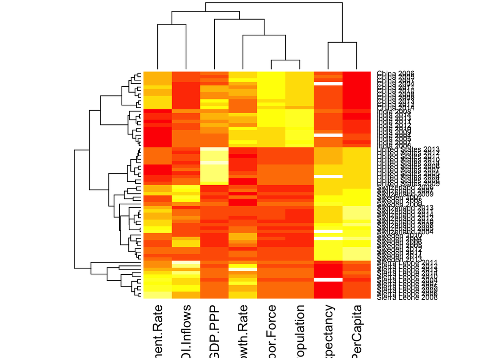

```r
scal.data1<-as.matrix(scale(data_numeric))
heatmap(scal.data1)
```

# Heat Map Results

We have the heat map shown above. The darker the color, the lower the value of the variable. The lighter the color, the higher the value of the variable. For e.g: Per.Capita Income is a lighter shade of yellow for countries like Sweden, Switzerland and United States, indicating a higher per capita income. As against Sierra Leone, India and China which have a lower per capita income reflected by the darker shade of red.

# Hierarchical cluster analysis

We used all of the data to perform the clustering and see if we got distinct clusters. The hclust function in R used the complete linkage method for hierarchical clustering by default. This particular clustering method defined the cluster distance between two clusters to be the maximum distance between their individual components. At every stage of the clustering process, the two nearest clusters are merged into a new cluster. The process is repeated until the whole data set is agglomerated into one single cluster.

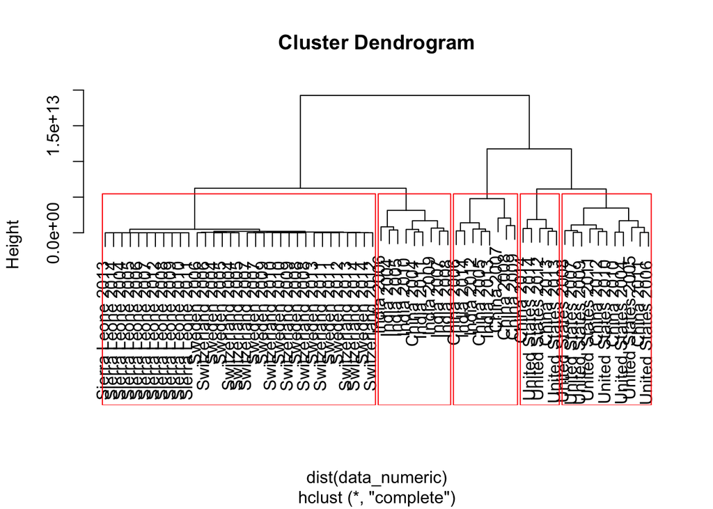

```r
hc<-hclust(dist(data_numeric))
plot(hc)
rect.hclust(hc, k = 5, border = "red")
```

# K-MEANS

We conducted the k-mean algorithm in 2 clusters, 3 clusters and 4 clusters. This gave us the category of 2, 3 and 4 clusters analysis.

```r
# First, we ruled out the rows with null values.
data2 <- na.omit(data1)
data1 <- na.omit(data1)

#Then we categorize the GDP into 3 categories in order to obtain and observe the confusion tables. Here, we took the GDP and Employment rate we were interested in.
data2$GDP.PPP = discretize(data2$GDP.PPP,categories = 3,labels = c("Poor","Developing","Developed"))
data2$Employment.Rate = discretize(data2$Employment.Rate,categories = 3,labels = c("Low","Medium","High"))
```

## 2 Clusters

```r
#K-means procedure
kmeans.result2 = kmeans(x=data1[, c('GDP.PPP','GDP.Growth.Rate','FDI.Inflows','Income.PerCapita',
                                    'Total.Population', 'Life.Expectancy','Labor.Force','Employment.Rate')],
                        centers = 2)
data2$kmeans.cluster2 = factor(kmeans.result2$cluster)

#Confusion Table
table(cluster = data2$kmeans.cluster2, actual = data2$GDP.PPP)
```

```
##        actual
## cluster Poor Developing Developed
##       1    0          3        15
##       2   37          5         0
```

## Results:

Let’s look at within the clusters. Cluster 1: China, United States Cluster 2: (China), India, Sierra Leone, Sweden, Switzerland Cluster 1 has the countries with relatively high GDP, like China and United States, whereas Cluster 2 has relatively low GDP.

## 3 Clusters

```r
#K-means procedure
kmeans.result3 = kmeans(x=data1[, c('GDP.PPP','GDP.Growth.Rate','FDI.Inflows','Income.PerCapita',
                                    'Total.Population', 'Life.Expectancy','Labor.Force','Employment.Rate')],
                        centers = 3)
data2$kmeans.cluster3 = factor(kmeans.result3$cluster)

#Confusion Table
table(cluster = data2$kmeans.cluster3, actual = data2$GDP.PPP)
```

```
##        actual
## cluster Poor Developing Developed
##       1    7          7         0
##       2   30          0         0
##       3    0          1        15
```

## 4 Clusters

```r
#K-means procedure
kmeans.result4 = kmeans(x=data1[, c('GDP.PPP','GDP.Growth.Rate','FDI.Inflows',
                                    'Income.PerCapita','Total.Population', 'Life.Expectancy','Labor.Force','Employment.Rate')],
                        centers = 4)
data2$kmeans.cluster4 = factor(kmeans.result4$cluster)

#Confusion table
table(cluster = data2$kmeans.cluster4, actual = data2$GDP.PPP)
```

```
##        actual
## cluster Poor Developing Developed
##       1   10          0         0
##       2   21          0         0
##       3    6          7         0
##       4    0          1        15
```